# Introducing R and Graphing Patent Data with ggplot2: Part 2

*Pie and Coxcomb Plots*

A pie chart is the plan view of a stacked bar chart using polar coordinates. Pie charts of the familiar variety are widely criticised because they are hard to accurately interpret. They also tend to become laden with what Edward Tufte called “chart junk”, such as 3D rendering, that distracts from the presentation and communication of the data. Edward Tufte has this to say about pie charts in The Visual Display of Quantitative Information:

> > > “A table is nearly always better than a dumb pie chart; the only worse design than a pie chart is several of them, for then the viewer is asked to compare quantities located in spatial disarray both within and between pies… Given their low data-density and failure to order numbers along a visual dimension, pie charts should never be used.”(Tufte 2001: 178)

However, Tufte’s criticism has done relatively little to diminish the popularity of the pie chart and it seems, almost everyone knows what a pie chart is.

The first step is to create an object as a stacked chart. In this case we attribute a single value to the x axis, specify the y axis as percent and then the fill as publication code. This creates a stacked bar chart.

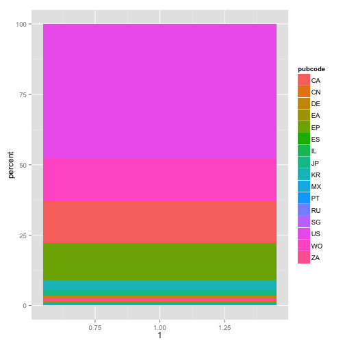

```r
o1 <- ggplot(pc, aes(x=1, y = percent, fill = pubcode)) + geom_bar(stat = "identity")
o1
```

If we view this it will be a stacked bar. In the second step we create the pie chart by specifying the polar coordinate and `theta = y`.

```r
y <- o1 + coord_polar(theta = "y")
```

If we now enter y in the console we will see a pie chart. The remaining steps involve further defining the aesthetics of the chart, tidying up and adding labels.

The following adds black lines to define the pie segments. Because these lines are then reflected in the legend the argument overrides this by using colour = NA.

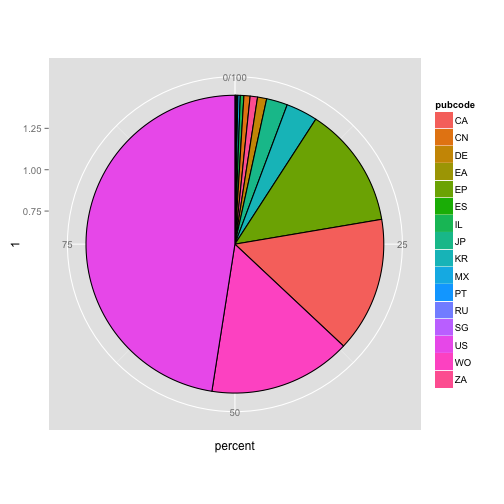

```r
z <- y + geom_bar(stat = "identity", colour = "black") +
  guides(fill=guide_legend(override.aes=list(colour=NA)))
z
```

Then remove the various tick marks

```r
z <- z +
    theme(axis.ticks=element_blank(),
          axis.title=element_blank(),
          axis.text.y=element_blank()
          )
z
```

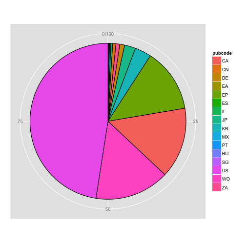

We need to work out the position of the labels that we would like to see on the pie, and in particular the mid-point of each pie. This can be found as the cumulative sum `cumsum` of the variable we used for the slices. That is percent expressed as `pc$percent` to state the data frame and the column we want in the `percent` table.

```r
y.breaks <- cumsum(pc$percent) - pc$percent/2
```

If we print y.breaks to the console we will a list of values.

```r
q <- z +
    theme(axis.text.x=element_text(color='black')) +
    scale_y_continuous(
        breaks=y.breaks,
        labels=pc$pubcode)
q
```

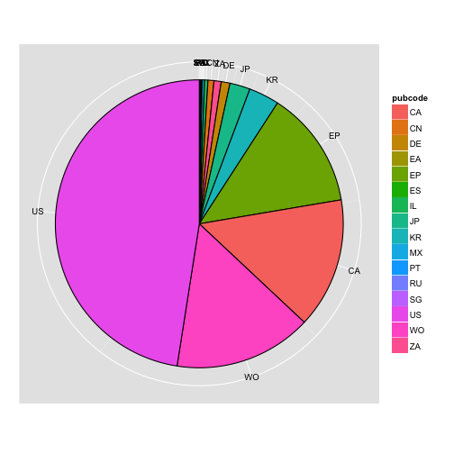

Thanks to Mathematical Coffee we now have a functional pie chart of the percentage share of pizza patent documents. The only issue with this plot is that some of the labels on the smaller values are crunched. That could however be addressed by filtering rows in accordance with the groups on the `pc` table, as we did above for `pcy`, to remove the overlap.

### The Coxcomb Plot

A coxcomb plot begins with a bar chart as follows. Note that we have chosen `n` for the y value from the table. We could have used percent.

￼￼We will use a filtered version of the table that only contains group 3 results.

```r
cx <- filter(pc, group %in% 3)
```

We start the plot by creating a bar chart. Note that we are using the value of `n` here for the y axis. This could be changed to percent or another value as needed.

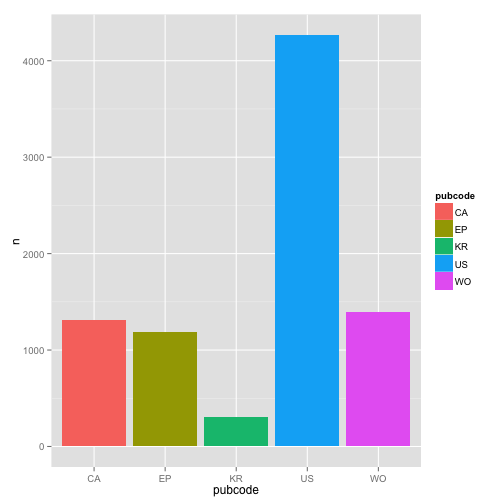

```r
cx1 <- ggplot(cx, aes(x = pubcode, y = n, fill= pubcode)) +
  geom_bar(stat="identity")
cx1
```

We them add a `coord_polar` specifying theta in this case as x (the pubcode). The remainder of the code is thematic.

```r
cx1 + coord_polar(theta="x") +
   theme_light() +
   theme(legend.position="none") +
   labs(x = "Publication Country", y = "Publication Count",
        title  = "Pizza Patent Publications by Country")
```

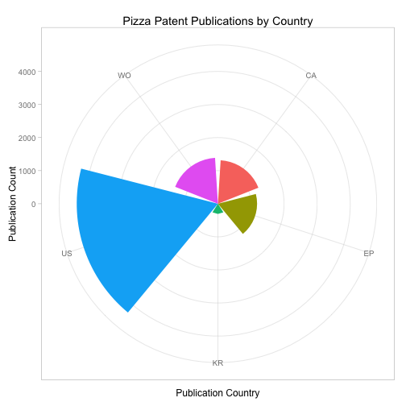

In the R Graphics Cookbook, Winston Chang adds three observations about coxcomb plots. The first is that for y variables the smallest value is mapped to the centre of the plot, rather than a data value of 0 being mapped to a radius of 0. Second, for a continuous x (or theta) the smallest and largest values are merged. Third, theta values of polar coordinates do not wrap around. As such changes would need to be made to the limits of the plot (see Chang 2013: 200-203 for discussion).

### Round Up

In this article we have covered two main topics.

1. How to prepare data for graphing in R using the `dplyr` package.
2. How to draw a range of graphs and the issues encountered using ggplot2.

In this article we have not explored the full potential of visualisation options in ggplot2, such as heat maps and choropleth maps. These topics are regularly covered on sites such as r-bloggers.com. However, we have seen that it is possible to construct graphics from the bottom up using simple code and specifying the details we would like to see.

We have seen that the great strength of ggplot2 is the ability to control all aspects of a graphic. However, in working with our sample data we have also seen that this can lead to complexity in terms of adjusting data such as arranging or labelling. While it will be possible to bundle the code into functions that could be reused, it is equally clear that significant time investments are involved in working towards publication quality graphics using ggplot2. Those time demands will diminish with improved familiarity but are nevertheless a significant factor.

To go further with ggplot2 we provide a list of resources below. We also suggest installing R tutorials such as (install.packages(“swirl”)) and learning more about the use of pipes in `dplyr`.

### Useful Resources

1. [RStudio Cheatsheet](http://www.rstudio.com/wp-content/uploads/2015/05/ggplot2-cheatsheet.pdf)
2. [R Graphics Cookbook](http://www.cookbook-r.com/Graphs/) by Winston Chang
3. [Hadley Wickham 2010 A Layered Grammar of Graphics preprint article](http://vita.had.co.nz/papers/layered-grammar.pdf)
4. [Hadley Wickham ggplot2 book from Amazon](http://www.amazon.co.uk/Hadley-Wickham/e/B002BOA9GI/ref=sr_tc_2_0?qid=1435678538&sr=1-2-ent)
5. Swirl tutorials (install.packages(“swirl”)) and [Github repository](https://github.com/swirldev/swirl_courses)
6. [ggplot2 online help topics](http://docs.ggplot2.org/0.9.3/index.html#)
7. [R-Bloggers on ggplot2](http://www.r-bloggers.com/search/ggplot2)
8. [Stack Overflow questions and answers on ggplot2](http://stackoverflow.com/questions/tagged/ggplot2)
9. [YouTube ggplot 2 videos](https://www.youtube.com/results?search_query=ggplot2)
10. [Mathematical Coffee Blog Post on Creating a Pie Chart with ggplot2 an the ggpie code](http://mathematicalcoffee.blogspot.co.uk/2014/06/ggpie-pie-graphs-in-ggplot2.html)